# 1. Stats de base, modèles linéaires, GLM

#### Exemple

Voici un exemple de GLM de Poisson avec de la surdispersion. Pour créer cette surdispersion, j’utilise une distribution négative binomiale pour générer les observations au lieu d’une distribution de Poisson.

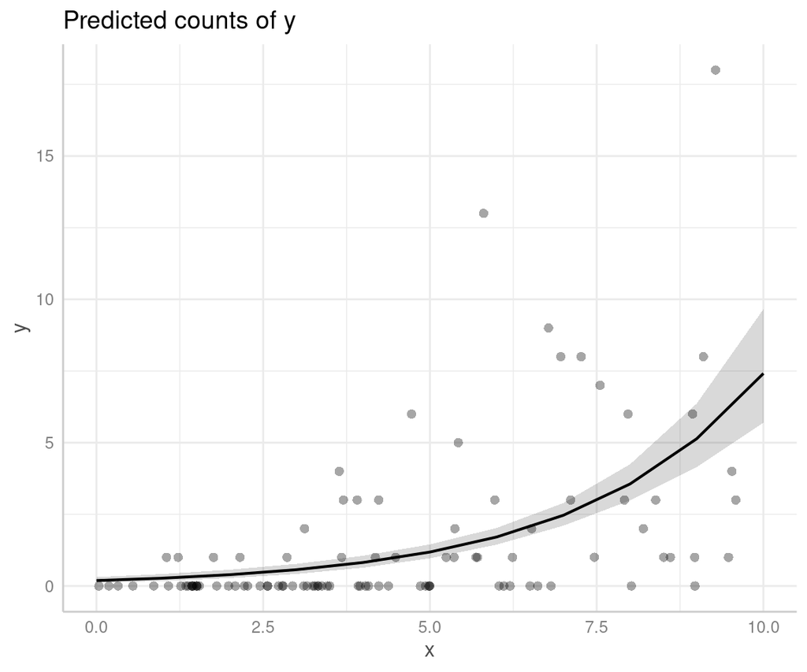

```r
n<-100
x<-runif(n,0,10)
lambda<-exp(-2+0.4*x)
y<-rnbinom(n,mu=lambda,size=0.5) #
d<-data.frame(y,x)

m<-glm(y~x,family="poisson",data=d)
g<-ggpredict(m,terms="x")
plot(g,show_data=TRUE)
```

#### Vérification avec DHARMa

Les résidus ne sont clairement pas distributés uniformément sur le second graphique et la surdispersion est évidente sur le 3e graphique.

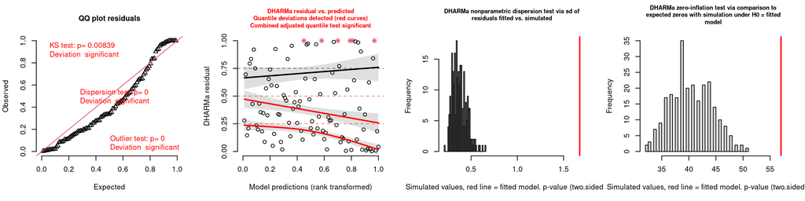

```r
s<-simulateResiduals(m)
par(mfrow=c(1,4))
testUniformity(s)
testQuantiles(s)
testDispersion(s)
testZeroInflation(s)
```

#### Correction avec glmmTMB

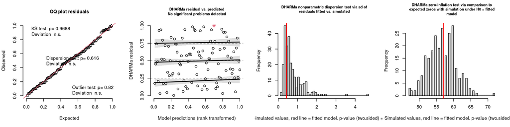

```r
library(glmmTMB)

m<-glmmTMB(y~x,family="nbinom2",data=d)

s<-simulateResiduals(m)

par(mfrow=c(1,4))
testUniformity(s)
testQuantiles(s)
testDispersion(s)
testZeroInflation(s)
```

### Sousdispersion

C’est lorsque les données sont moins variables que ce qui est attendu par le modèle. Ceci est beaucoup plus rare et probablement moins dommageable (e.g. taille de couvée/portée chez les oiseaux/mammifères voir [Brooks et al. 2019](https://doi.org/10.1002/ecy.2706)).

En général, une sous-dispersion ignorée fera en sorte que l’incertitude sera surestimée (trop conservateurs dans nos résultats) ce qui est un moindre mal.

Solutions:

Poisson -> `glmmTMB, family = "compois"`

### Zéro-inflation

Surabondance de 0 dans les observations par rapport à ce qui est attendu par le modèle. Il est possible aussi d’avoir une sous-abondance de 0 et/ou encore une surabondance de 1, mais ce dernier cas est un peu plus rare.

Solutions:

modèle *zero-inflated* (`glmmTMB`,`pscl`,`brms`, etc.)

À noter qu’une surdipersion peut être due à une surabondance de 0 et vice-versa. Ce sont deux problèmes qui peuvent interagir.

### Extensions

**Gamma** $]0,\infty$

Variable réponse continue, strictement positive et avec une asymétrie à droite.

Souvent une alternative à une transformation $log$.

Ex.: concentration d’un composé, biomasse, etc.

**Tweedie** $[0,\infty$

Variable réponse continue positive et incluant des 0.

Ex.: biomasse capturée, précipitations, etc.

Voir [Lecomte et al. 2013](https://doi.org/10.1111/2041-210X.12122)

**Beta** $]0,1[$ ou $[0,1]$

Variable continue entre 0 et 1 exclusivement.

Pour proportion ou % ne provenant pas d’un ratio entre entiers.

Si 0 et 1 possibles, certaines transformations peuvent être utilisées.

Ex.: proportion d’une surface affectée, proportion de temps passé en alimentation, etc.

Voir [Douma & Weedon 2019](https://doi.org/10.1111/2041-210X.13234)

# 2. Modèles mixtes/hiérarchiques

$$y = \alpha + \beta x +
\epsilon$$

$$\epsilon \sim \text{Normale}(0,\sigma^{2})$$

ou

$$\mu = \alpha + \beta x$$

$$y \sim \text{Normale}(\mu,\sigma^{2})$$

## Modèle linéaire hiérarchique simple

$$y_{ij} = \alpha + \beta x_{ij}
+ \tau_{i} + \epsilon_{ij}$$

$$\tau_{i} \sim
\text{Normale}(0,\,\sigma_{\tau}^{2})$$

$$\epsilon_{ij} \sim
\text{Normale}(0,\sigma_{\epsilon}^{2})\$$

où il y a $i$ groupes et $j$ observations par groupe

## Autre formulation

$$\mu_{ij} = \alpha_{i} + \beta
x_{ij}$$

$$\alpha_{i} \sim
\text{Normale}(\alpha,\,\sigma_{\alpha}^{2})\$$

$$y_{ij} \sim
\text{Normale}(\mu_{ij},\,\sigma_{\epsilon}^{2})\$$

Un modèle est dit hiérarchique lorsque certains de ses paramètres sont définis par une distribution de probabilité.

## Simulons un exemple

```r
set.seed(12345)
ng <- 20
nobs <- 10
n <- ng * nobs
id <- gl(ng, nobs)

# valeurs fictives des variables explicatives selon une distribution uniforme
x <- runif(n, 0, 100)

# valeurs des paramètres
a <- 100
b <- 1

# on génère l'effet aléatoire pour chaque groupe
rea <- rep(rnorm(ng, 0, 20), each = nobs)

# prédicteur linéaire
mu <- (a + rea) + b * x

# observations à partir d'une distribution normale avec un écart-type de 5
y <- rnorm(n, mu, 5)

# données
d <- data.frame(y, x)
```

## Illustrons le modèle

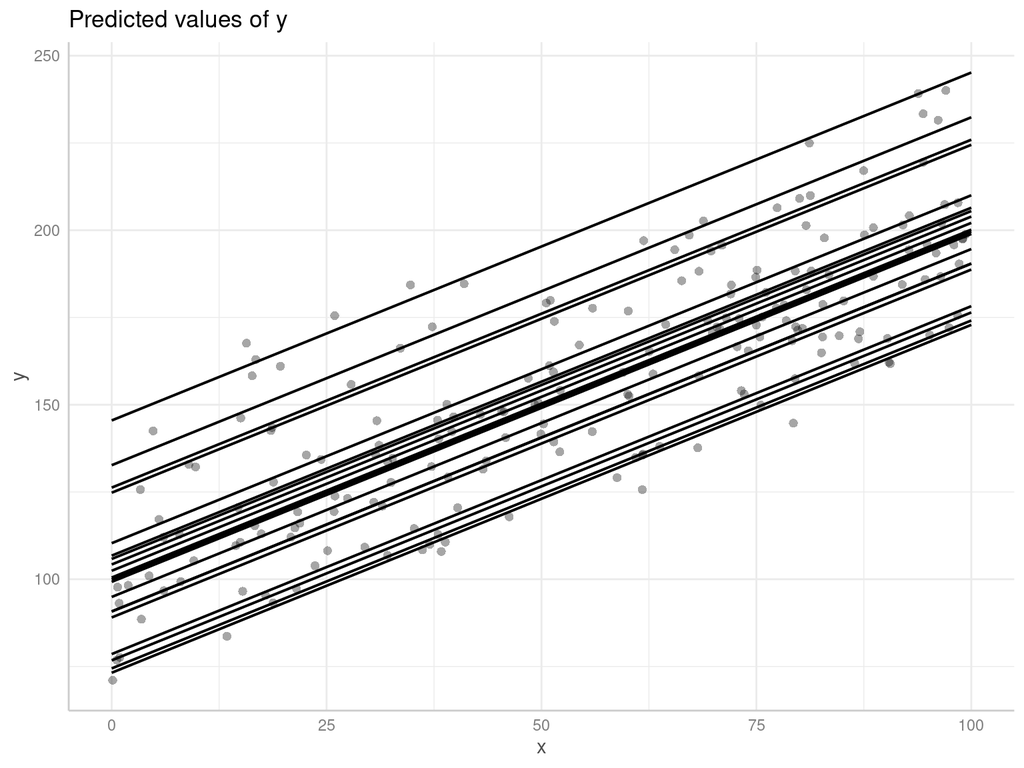

```r
library(lme4)
library(ggeffects)

m <- lmer(y ~ x + (1|id), data = d)

g <- ggpredict(m, terms = c("x", "id [sample=20]"), type = "random")
plot(g, show_data = TRUE, show_ci = FALSE, colors = rep("black", 20), show_legend = FALSE)
```

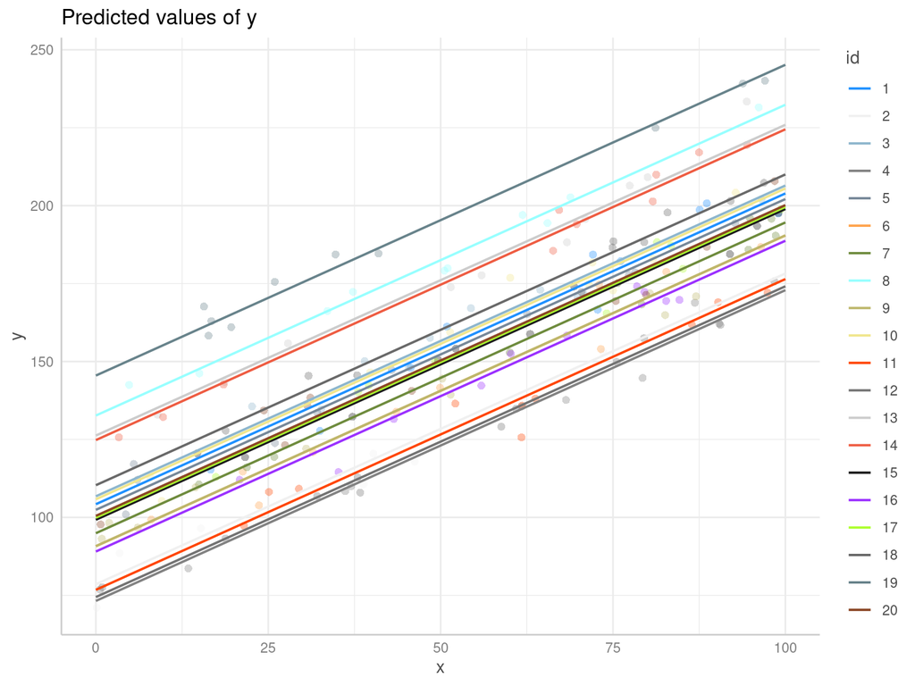

```r
g <- ggpredict(m, terms = c("x", "id [sample=20]"), type = "random")
plot(g, show_data = TRUE, show_ci = FALSE, colors = sample(colors(), 20))
```

## Retrouvons les paramètres

La variance de l’effet aléatoire était de 20² et la variance résiduelle était de 5².

```r
summary(m)
```

```
## Linear mixed model fit by REML ['lmerMod']
## Formula: y ~ x + (1 | id)
##    Data: d
##
## REML criterion at convergence: 1314.6
##
## Scaled residuals:
##      Min       1Q   Median       3Q      Max
## -2.50905 -0.67270 -0.04039  0.61012  2.58655
##
## Random effects:
##  Groups   Name        Variance Std.Dev.
##  id       (Intercept) 386.9    19.67
##  Residual              25.3     5.03
## Number of obs: 200, groups:  id, 20
##
## Fixed effects:
##              Estimate Std. Error t value
## (Intercept) 101.35098    4.46512   22.70
## x             0.99676    0.01262   78.97
##
## Correlation of Fixed Effects:
##   (Intr)
## x -0.153
```

## Récupérons ces effets

```r
fixef(m)
```

```
## (Intercept)           x
## 101.3509752   0.9967622
```

```r
ranef(m)
```

```
## $id
##    (Intercept)
## 1    2.8823702
## 2  -22.7874952
## 3    5.4199340
## 4  -28.1373544
## 5    1.0787346
## 6  -10.6043879
## 7   -6.4207965
## 8   31.3275567
## 9  -10.5628148
## 10   4.4707573
## 11 -24.5843971
## 12 -26.8974001
## 13  24.9063468
## 14  23.4502635
## 15  -2.0989706
## 16 -12.2974161
## 17  -1.4157682
## 18   8.9803887
## 19  44.1496752
## 20  -0.8592262
##
## with conditional variances for "id"
```

```r
apply(ranef(m)$id, 2, sd)
```

```
## (Intercept)
##    19.60505
```

## Coefficients

```r
coef(m)
```

```
## $id
##    (Intercept)         x
## 1    104.23335 0.9967622
## 2     78.56348 0.9967622
## 3    106.77091 0.9967622
## 4     73.21362 0.9967622
## 5    102.42971 0.9967622
## 6     90.74659 0.9967622
## 7     94.93018 0.9967622
## 8    132.67853 0.9967622
## 9     90.78816 0.9967622
## 10   105.82173 0.9967622
## 11    76.76658 0.9967622
## 12    74.45358 0.9967622
## 13   126.25732 0.9967622
## 14   124.80124 0.9967622
## 15    99.25200 0.9967622
## 16    89.05356 0.9967622
## 17    99.93521 0.9967622
## 18   110.33136 0.9967622
## 19   145.50065 0.9967622
## 20   100.49175 0.9967622
##
## attr(,"class")
## [1] "coef.mer"
```

## Complexifions le modèle

```r
b
```

```
## [1] 1
```

```r
reb <- rep(rnorm(ng, 0, 0.5), each = nobs)

mu <- (a + rea) + (b + reb) * x

y <- rnorm(n, mu, 5)

d <- data.frame(y, x)
```

## Illustrons les pentes

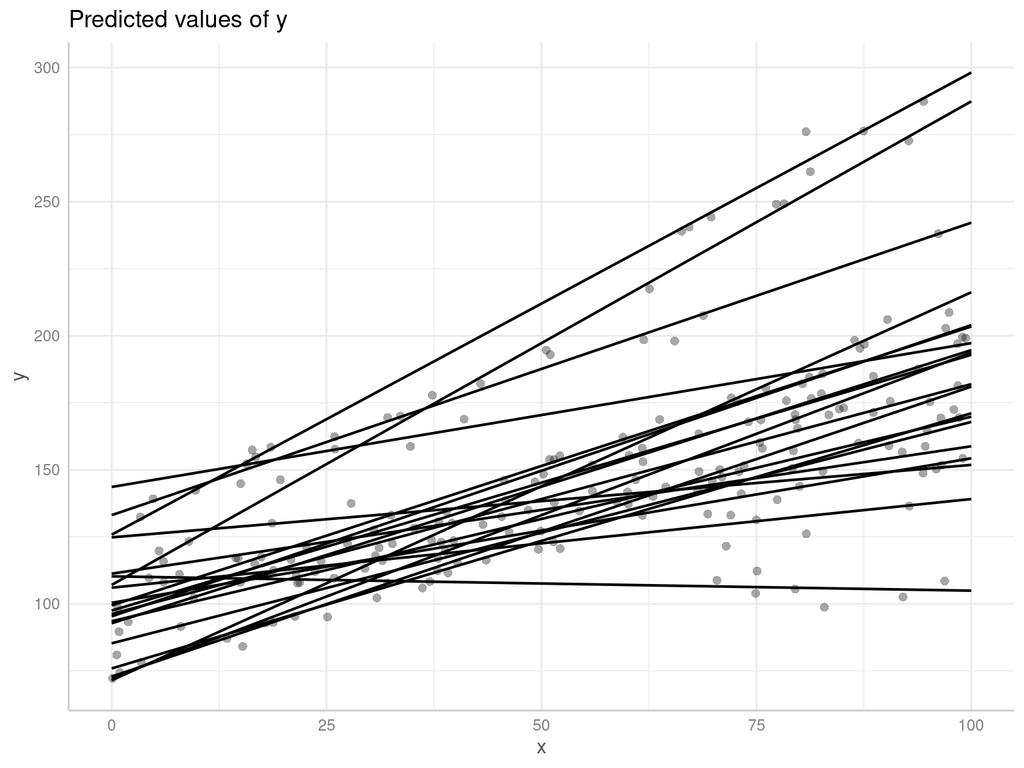

```r
m <- lmer(y ~ x + (x|id), data = d)

g <- ggpredict(m, terms = c("x", "id [sample=20]"), type = "random")
plot(g, show_data = TRUE, show_ci = FALSE, colors = rep("black",20), show_legend = FALSE)
```

## Retrouvons les paramètres

La variance de l’effet aléatoire sur la pente était de (0.5)².

```r
summary(m)
```

```
## Linear mixed model fit by REML ['lmerMod']
## Formula: y ~ x + (x | id)
##    Data: d
##
## REML criterion at convergence: 1380.3
##
## Scaled residuals:
##      Min       1Q   Median       3Q      Max
## -2.65972 -0.59301 -0.02689  0.67210  2.34966
##
## Random effects:
##  Groups   Name        Variance Std.Dev. Corr
##  id       (Intercept) 423.3638 20.5758
##           x             0.2206  0.4697  -0.27
##  Residual              23.0355  4.7995
## Number of obs: 200, groups:  id, 20
##
## Fixed effects:
##             Estimate Std. Error t value
## (Intercept) 100.7498     4.6649  21.598
## x             0.8978     0.1058   8.488
##
## Correlation of Fixed Effects:
##   (Intr)
## x -0.278
```

## Récupérons ces effets

```r
fixef(m)
```

```
## (Intercept)           x
## 100.7498388   0.8977862
```

```r
ranef(m)
```

```
## $id
##    (Intercept)           x
## 1   -1.3212508  0.14250446
## 2  -27.8833340  0.18370803
## 3   10.5112084 -0.42265042
## 4  -24.8340891  0.05391345
## 5    6.3066056  0.90594095
## 6  -15.4825083 -0.07194666
## 7   -7.2264532 -0.13482824
## 8   32.3404879  0.19292392
## 9   -5.4085764  0.18854151
## 10   5.2749026 -0.56709079
## 11 -29.2471422  0.54929391
## 12 -28.3343158  0.31550216
## 13  24.0498650 -0.62751548
## 14  25.0509921  0.82592806
## 15  -0.3558966 -0.35897596
## 16  -7.9994965  0.12123447
## 17  -3.2679815  0.05636244
## 18   9.4998210 -0.95114744
## 19  42.8513291 -0.36123227
## 20  -4.5241675 -0.04046612
##
## with conditional variances for "id"
```

```r
apply(ranef(m)$id, 2, sd)
```

```
## (Intercept)           x
##  20.2965609   0.4664978
```

```r
coef(m)
```

```
## $id
##    (Intercept)           x
## 1     99.42859  1.04029063
## 2     72.86650  1.08149421
## 3    111.26105  0.47513575
## 4     75.91575  0.95169963
## 5    107.05644  1.80372713
## 6     85.26733  0.82583952
## 7     93.52339  0.76295793
## 8    133.09033  1.09071010
## 9     95.34126  1.08632769
## 10   106.02474  0.33069538
## 11    71.50270  1.44708008
## 12    72.41552  1.21328834
## 13   124.79970  0.27027070
## 14   125.80083  1.72371424
## 15   100.39394  0.53881021
## 16    92.75034  1.01902065
## 17    97.48186  0.95414862
## 18   110.24966 -0.05336126
## 19   143.60117  0.53655391
## 20    96.22567  0.85732006
##
## attr(,"class")
## [1] "coef.mer"
```

## Formulations

```r
m <- lmer(y ~ x + (1|id), data = d)

m <- lmer(y ~ x + (x|id), data = d) # équivalent à (1 + x|id)

m <- lmer(y ~ x + (0 + x|id), data = d)

m <- lmer(y ~ x + (1|id) + (0 + x|id), data = d)
```

## Corrélations *intercepts*/pentes

```r
m <- lmer(y ~ x + (1|id) + (0 + x|id), data = d)
```

Le dernier est équivalent à

```r
m <- lmer(y ~ x + (x||id), data = d)
```

et signifie qu’on assume que l’*intercept* et la pente ne sont pas corrélées ou qu’on ne veut pas estimer cette corrélation. En pratique, il n’y a pas énormément de raison de faire cela et par défaut le modèle va estimer cette corrélation.

## Effets aléatoires croisés

Supposons que nous avons des individus observés plusieurs fois par année et ce sur plusieurs années.

```r
m <- lmer(y ~ x + (1|id) + (1|year), data = d)
```

## Effets aléatoires nichés

Supposons maintenant que les individus sont annuels et qu’ils ne sont observés que pour des années particulières.

```r
m <- lmer(y ~ x + (1|year/id), data = d)
```

Équivalent à:

```r
m <- lmer(y ~ x + (1|year) + (1|year:id), data = d)
```

## Quand utiliser les effets aléatoires?

- Mesures répétées sur certaines unités ou individus
- Les observations sont regroupées sous des structures ou ne sont pas indépendantes
- Il y a de la réplication à plusieurs niveaux de la hiérarchie
- On veut estimer la variance ou généraliser à une population d’unités d’échantillonnage

## Formulation matricielle

$$\mu_{ij} = \alpha_{i} + \beta
x_{ij}$$

$$\alpha_{i} \sim
\text{Normale}(\alpha,\,\sigma_{\alpha}^{2})$$

$$y_{ij} \sim
\text{Normale}(\mu_{ij},\,\sigma_{\epsilon}^{2})$$

De façon plus générale:

$$\boldsymbol{y} \sim
\text{Normale}(\mathbf{\boldsymbol{\beta}}\mathbf{X},
\mathbf{I}\sigma^2)$$

$$\boldsymbol{y} \sim
\text{Normale}(\mathbf{\boldsymbol{\beta}}\mathbf{X},
\mathbf{\Sigma})$$

## Structure de covariance

Si on a 20 groupes avec 10 observations par groupe, la matrice de covariance $\mathbf{\Sigma}$ est diagonale par blocs avec 20 groupes identiques de taille $10 \times 10$ :

$$\mathbf{\Sigma}
=
\begin{pmatrix}
\mathbf{\Sigma}_1 & 0 & \cdots & 0 \\
0 & \mathbf{\Sigma}_2 & \cdots & 0 \\
\vdots & \vdots & \ddots & \vdots \\
0 & 0 & \cdots & \mathbf{\Sigma}_{20}
\end{pmatrix}$$

Chaque groupe a une variance totale de :

$$\mathbf{\Sigma}_i
=
\sigma_\alpha^2 \mathbf{J}_{10}
+
\sigma_\epsilon^2 \mathbf{I}_{10}$$

où

- $\mathbf{J}_{10}$ est une matrice $10 \times 10$ de 1
- $\mathbf{I}_{10}$ est la matrice identité $10 \times 10$

Pour chaque groupe on a donc:

$$\mathbf{\Sigma}_i =
\begin{pmatrix}
\sigma_\alpha^2 + \sigma_\epsilon^2 & \sigma_\alpha^2 & \cdots
& \sigma_\alpha^2 \\
\sigma_\alpha^2 & \sigma_\alpha^2 + \sigma_\epsilon^2 & \cdots
& \sigma_\alpha^2 \\
\vdots & \vdots & \ddots & \vdots \\
\sigma_\alpha^2 & \sigma_\alpha^2 & \cdots & \sigma_\alpha^2
+ \sigma_\epsilon^2
\end{pmatrix}$$

## Variance et covariance

Donc, au sein d’un même groupe :

$$\mathrm{Var}(y_{ij}) = \sigma_\alpha^2 + \sigma_\epsilon^2$$

$$\mathrm{Cov}(y_{ij}, y_{ik}) = \sigma_\alpha^2
\quad (j \neq k)$$

Entre les groupes :

$$\mathrm{Cov}(y_{ij}, y_{lk}) = 0
\quad (i \neq l)$$

## Régularisation (*shrinkage*)

*Complete pooling*

Un seul modèle pour tous, on ignore les différences entre les groupes

*No pooling*

Un seul modèle par groupe, on estime un paramètre pour chaque groupe et ces paramètres sont indépendants

*Partial pooling*

Un seul modèle par groupe, mais les paramètres pour chaque groupe sont influencés par un modèle et les estimations sont tirées vers une valeur commune

## Un exemple

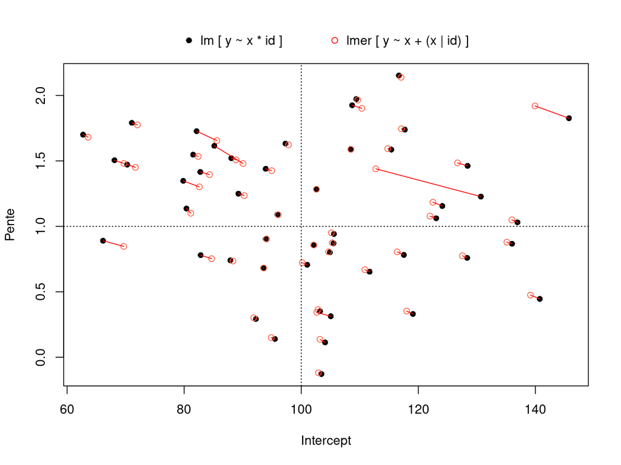

## Effet du n

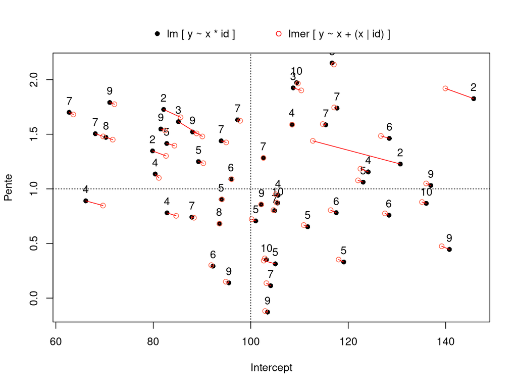

## Effet spatial, temporel, phylogénétique

Autocorrélation spatiale, temporelle, phylogénétique, etc…

## Structure d’erreur spatiale

Si on a:

$$\boldsymbol{y} \sim
\text{Normale}(\mathbf{\boldsymbol{\beta}}\mathbf{X},
\mathbf{\Sigma})$$
on peut définir la matrice de covariance par une fonction de corrélation spatiale:

$$\Sigma_{ij} = \text{Cov}(y_i, y_j) =
\sigma^2 \, \rho(d_{ij})$$

où

- $d_{ij}$ est la distance entre les localisations $y_i$ et $y_j$
- $\sigma^2$ est la variance marginale
- $\rho()$ est la fonction de corrélation spatiale

## Corrélation spatiale exponentielle

$$\rho(d) =
\exp\left(-\frac{d}{\phi}\right)$$
où $\phi > 0$ est l’étendue de la corrélation spatiale (*range*) et la covariance devient:
$$\Sigma_{ij} = \sigma^2
\exp\left(-\frac{d_{ij}}{\phi}\right)$$

## Corrélation spatiale exponentielle

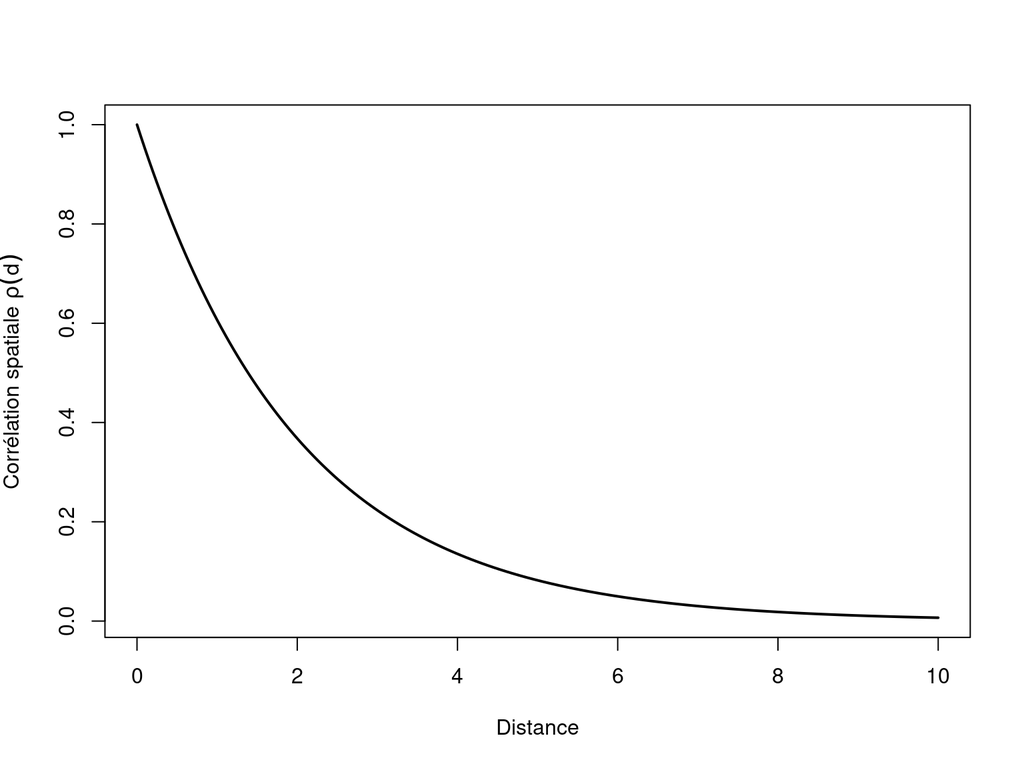

```r
phi <- 2
d <- seq(0, 10, length.out = 200)
rho <- exp(-d / phi)
plot(d, rho, type = "l", lwd = 2, xlab = "Distance", ylab = expression("Corrélation spatiale" ~ rho(d)))
```

L’indépendence entre les observations croit avec la distance

## Formulation matricielle

Le modèle peut être écrit sous forme matricielle :

$$\boldsymbol{y} \sim
\text{Normale}(\boldsymbol{\beta}\mathbf{X}, \mathbf{\Sigma})$$
avec
$$\mathbf{\Sigma} =
\sigma^2
\begin{pmatrix}
1 & e^{-d_{12}/\phi} & e^{-d_{13}/\phi} & \cdots \\
e^{-d_{21}/\phi} & 1 & e^{-d_{23}/\phi} & \cdots \\
e^{-d_{31}/\phi} & e^{-d_{32}/\phi} & 1 & \cdots \\
\vdots & \vdots & \vdots & \ddots
\end{pmatrix}$$

On estimera ici $\sigma^2$ et le paramètre $\phi$ qui détermineront la variation entre les observations.

## Interprétation

- Les observations proches dans l’espace sont fortement corrélées.
- La corrélation décroît progressivement lorsque la distance augmente.
- Lorsque $d_{ij} \to \infty$, la covariance tend vers 0.
- Lorsque $\phi$ est grand, la dépendance spatiale s’étend sur de longues distances.

## Problèmes, questionnements ?

**La GLMM FAQ!**

[https://bb.olker.github.io/mixedmodels-misc/glmmFAQ.html](https://bbolker.github.io/mixedmodels-misc/glmmFAQ.html)

# 3. Vraisemblance et statistiques bayésiennes

## Rappel des probabilités

Quelle est la probabilité d’obtenir 2 fois pile en tirant une pièce de monnaie 2 fois?

### Pile ou face

On doit multiplier la probabilité de chaque événement pour obtenir la probabilité combinée de ces deux événements. Si $P(pile) = 0.5$ (*i.e.* la probabilité d’obtenir pile), on a:

$$P(pile,pile) = P(pile) \times
P(pile) = 0.5 \times 0.5 = 0.25$$

### Avec R

On peut calculer ceci avec R et la fonction `dbinom`.

```r
dbinom(0,size=1,p=0.5) * dbinom(0,size=1,p=0.5)
```

```
## [1] 0.25
```

On peut également appliquer la fonction `dbinom` à un vecteur de valeur. Ceci nous donne un vecteur de (densité de) probabilité et on peut multiplier ces valeurs entre elles avec la fonction `prod`.

```r
prod(dbinom(c(0,0),size=1,p=0.5))
```

```
## [1] 0.25
```

## Vraisemblance

La vraisemblance (*likelihood*) représente la plausibilité de valeurs de paramètres en fonction de données observées. L’utilisation de la vraisemblance implique l’utilisation de distribution de probabilités pour représenter le lien entre les observations et les modèles.
Pour quantifier la vraisemblance, on peut utiliser une fonction de vraisemblance (*likelihood function*).
$$L(\theta|data) = P(data|\theta)$$
$data$: données
$\theta$: paramètres du modèle
$L(\theta|data)$: fonction de vraisemblance
$P(data|\theta)$: vraisemblance (*likelihood*)

Ici, $L(\theta|data)$ est la fonction de vraisemblance et l’équation précédente nous dit que la vraisemblance des paramètres conditonnelle aux paramètres $\theta$ est égale à la (densité de) probabilité des données conditionnelle aux paramètres $\theta$.

### Maximum de vraisemblance

L’idée derrière le maximum de vraisemblance (*maximum likelihood*) est de déterminer la valeur des paramètres qui rend l’observation des données la plus probable.

Une grande partie des paramètres que nous estimons sont estimés par la méthode du maximum de vraisemblance.  
Certaines méthodes plus classiques comme la minimisation de la somme des carrés dans la régression standard sont équivalentes à la maximisation de la vraisemblance. La sélection de modèles par AIC repose sur l’utilisation du maximum de vraisemblance.

### Exemple

Simulons `n = 20` présences/absences avec une probabilité de `p = 0.5`. Ensuite, calculons la vraisemblance d’observer les données générées en fonction de plusieurs valeurs du paramètre p, qui ici est une probabilité.

```r
set.seed(123)
p<-0.5
y<-rbinom(20,1,p) # tirage aléatoire de 20 valeurs de 0/1 avec une probabilité de 0.5

probs<-seq(0,1,by=0.01) # valeurs du paramètre qui seront évaluées
l<-sapply(probs,function(i){
  prod(dbinom(y,size=1,prob=i)) # likelihood
})
```

Pour calculer la vraisemblance, on utilise la fonction dbinom qui permet de calculer pour chaque valeur observée une (densité de) probabilité. En calculant le produit `prod` de toutes ces valeurs, on obtient la valeur de la fonction de vraisemblance pour l’observation de l’ensemble de ces données pour une valeur donnée du paramètre `p`. On calcule ensuite ces valeurs de vraisemblance pour un ensemble de valeur de `p`.

### Profil de vraisemblance

Par la suite, on peut illustrer la vraisemblance d’obtenir les valeurs observées pour les différentes valeurs de `p`. Ceci permet d’illustrer le profile de vraisemblance (*likelihood profile*).

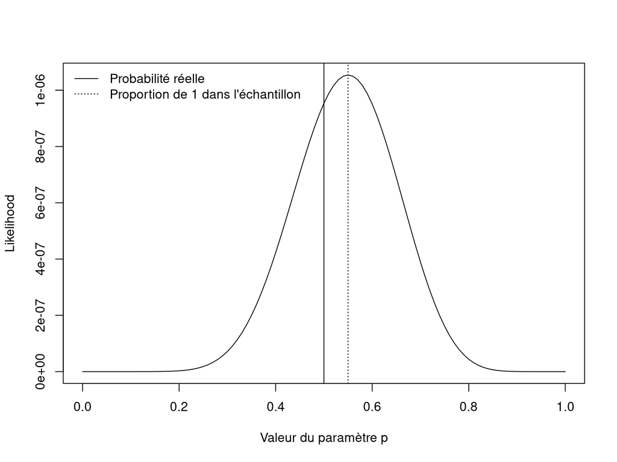

```r
plot(probs,l,type="l",ylab="Likelihood",xlab="Valeur du paramètre p")
abline(v=sum(y)/length(y),lty=3)
abline(v=0.5)
legend("topleft",lty=c(1,3),legend=c("Probabilité réelle","Proportion de 1 dans l'échantillon"),bty="n")
```

```r
probs[which.max(l)]
```

```
## [1] 0.55
```

Le maximum de cette courbe est le maximum de vraisemblance (*maximum likelihood*), i.e. la valeur de `p` pour laquelle la probabilité d’observer les données est la plus grande. Dans ce cas précis, cette valeur est la proportion de 1 dans les données. La plupart des paramètres que nous estimons sont obtenus avec cette méthode.

### Avec un glm

Voici ce qu’on obtient avec un glm si on tente d’estimer cette probabilité. En principe, l’intercept représente cette probabilité, mais elle est sur l’échelle logit $log(p/(1-p))$. Il faut donc retransformer le tout sous l’échelle d’une probabilité avec une fonction logit inverse.

```r
m<-glm(y~1,family=binomial)
summary(m)
```

```
##
## Call:
## glm(formula = y ~ 1, family = binomial)
##
## Coefficients:
##             Estimate Std. Error z value Pr(>|z|)
## (Intercept)   0.2007     0.4495   0.446    0.655
##
## (Dispersion parameter for binomial family taken to be 1)
##
##     Null deviance: 27.526  on 19  degrees of freedom
## Residual deviance: 27.526  on 19  degrees of freedom
## AIC: 29.526
##
## Number of Fisher Scoring iterations: 3
```

```r
exp(coef(m))/(1+exp(coef(m)))
```

```
## (Intercept)
##        0.55
```

### Intervalle de confiance

On peut également estimer un intervalle de confiance autour de cette probabilité avec la fonction `confint.` Différentes méthodes existent pour obtenir un intervalle de confiance à partir d’un profil de vraisemblance, mais nous n’arborderons pas cela ici (*i.e.* *profile likelihood confidence intervals*).

```r
ci<-confint(m) # calcul de l'intervalle de confiance sur les coefficients
ci<-c(coef(m),ci) # intercept est l'estimation de la probabilité p
c(exp(ci)/(1+exp(ci))) # intervalle de confiance
```

```
## (Intercept)       2.5 %      97.5 %
##   0.5500000   0.3359294   0.7519795
```

### Log de la vraisemblance

Pour des raisons pratiques, on va souvent maximiser le *log* de la vraisemblance (*log-likelihood*) pour éviter des problèmes numériques associés aux très petites valeurs. On parle donc souvent de *log-likelihood* (*LL*, *logLik*, etc.).  
Par exemple, on peut comparer la vraisemblance calculée par le glm à celle que nous avons calculée “à la mitaine” avec la fonction `dbinom` pour la valeur du paramètre qui maximise cette vraisemblance (`p = 0.55`).

```r
prod(dbinom(y,size=1,prob=0.55))
```

```
## [1] 1.05415e-06
```

```r
exp(logLik(m))
```

```
## 'log Lik.' 1.05415e-06 (df=1)
```

## Probabilités conditionnelles

Voyons d’abord ce qu’est une probabilité conditionnelle.
$$P(A|B)$$
Ici, on représente la probabilité de $A$ considérant que $B$ s’est produit. Par exemple, quelle est la probabilité d’être infecté par la Covid-19 si on reçoit un test positif.
$$P(\textrm{infecté}|\textrm{test
positif})$$
On pourrait aussi s’intéresser à la probabilité d’avoir un test positif si on est effectivement infecté.
$$P(\textrm{test
positif}|\textrm{infecté})$$

### Règle de Bayes

Il s’agit simplement d’une règle en théorie des probabilités qui permet de relier des probabilités conditionnelles.
$$P(A|B) = \frac{P(B|A)P(A)}{P(B)}$$

$P(A)$ veut dire la probabilité de $A$, indépendemment de $B$.  
$P(A|B)$ veut dire la probabilité de $A$ sachant $B$. C’est une probabilité conditionnelle.

### Interprétation

Un exemple classique de cette règle est le suivant. Supposons que $P(A)$ désigne la probabilité d’être infecté par la Covid-19 et que $P(B)$ désigne la probabilité de tester positif à un test de Covid-19. Ici, on a aussi $P(A')$ qui est la probabilité de ne pas être infecté et $P(B')$ qui est la probabilité d’un test négatif.  
Si on a:  
$P(A) = 1/500 = 0.002$: proportion de personnes infectées

$P(A') = 1-1/500 = 0.998$: proportion de personnes qui ne sont pas infectées

$P(B|A) = 0.98$: probabilité d’un test positif si une personne est infectée

$P(B|A') = 0.05$: probabilité d’un test positif si une personne n’est pas infectée

$P(B) = P(B|A)P(A) + P(B|A')P(A')$: il faut additionner les possibilités associées au cas où une personne est infectée et au cas où une personne n’est pas infectée.

Quelle est la probabilité d’être infecté si on reçoit un test positif (en assumant qu’on se fait tester pour une raison autre que d’avoir des symptômes) ?

$$P(A|B) =
\frac{P(B|A)P(A)}{P(B|A)P(A)+P(B|A')P(A')} = \frac{0.98 \times
0.002}{(0.98 \times 0.002) + (0.05 \times 0.998)} \approx
0.0378$$

Dans ce cas fictif, la probabilité d’avoir réellement la Covid-19 si le test est positif n’est que d’environ 3.78 %

## Statistiques bayésiennes

Les statisiques bayésiennes se basent sur cette règle pour faire une **inteprétation probabiliste des paramètres** à partir des données.
$$P(\theta|data) =
\frac{P(data|\theta)P(\theta)}{P(data)}$$
$data$: données
$\theta$: paramètres du modèle
$P(\theta|data)$: distribution postérieure (*posterior*)
$P(data|\theta)$: vraisemblance (*likelihood*)
$P(\theta)$: distribution *a priori* (*prior*)
$P(data)$: distribution marginale des données (*marginal likelihood*)

### Distribution postérieure (*posterior*)

$$P(\theta|data) =
\frac{P(data|\theta)P(\theta)}{P(data)}$$
La distribution postérieure $P(\theta|data)$ est ce que l’on cherche à estimer. Il s’agit d’une distribution de probabilité qui décrit les probabilités des différentes valeurs possibles du paramètre. Contrairement aux analyses fréquentistes, on peut directement parler de la probabilité qu’un paramètre soit entre telle et telle valeur.

### Vraisemblance (*likelihood*)

$$P(\theta|data) =
\frac{P(data|\theta)P(\theta)}{P(data)}$$
Comme vu précédemment, la vraisemblance $P(data|\theta)$ représente la probabilité des données conditionnelles à des valeurs de paramètres $\theta$.

### Distribution *a priori* (*priors*)

$$P(\theta|data) =
\frac{P(data|\theta)P(\theta)}{P(data)}$$
Les distributions *a priori* $P(\theta)$ représentent nos croyances ou nos connaissances sur les valeurs des paramètres avant de faire les analyses. On les représente à l’aide de distributions de probabilité. Ces croyances représentent ce à quoi on s’attend en termes de valeurs en se basant sur nos connaissances avant de faire notre expérience.

### Distribution marginale des données

$$P(\theta|data) =
\frac{P(data|\theta)P(\theta)}{P(data)} =
\frac{P(data|\theta)P(\theta)}{\int
P(data|\theta)P(\theta)d\theta}$$
Cette quantité $P(data)$ (*marginal likelihood*) est beaucoup plus difficile à comprendre intuitivement. Elle représente en quelque sorte la probabilité des données pour l’ensemble des valeurs de paramètres possibles (d’où l’intégrale). C’est la distribution marginale des données ou la vraisemblance marginale. Elle permet également de faire en sorte que la distribution postérieure soit une distribution de probabilité (i.e. aire sous la courbe = 1).
Il s’agit d’une constante qui est généralement très difficile à calculer. Des méthodes comme le MCMC permettent d’éviter de la calculer directement dans l’obtention de la distribution postérieure.

### En résumé

$$Posterior = \frac{Likelihood \times
Prior}{Marginal\;Likelihood}$$

Puisque le dénominateur est une constante et que dans bien des cas, on peut éviter de le calculer, on peut plus simplement écrire:

$$Posterior \propto Likelihood \times
Prior$$

En d’autres mots, la distribution postérieure est proportionnelle à la vraisemblance et aux distributions *a priori*

On pourrait aussi dire qu’avec une approche bayésienne, on met à jour nos croyances ou nos connaissances à l’aide de données.

## Avantages

- Interprétation probabiliste plus facile (e.g. intervalle de confiance fréquentiste vs. bayésien)
- Facilite l’estimation de modèles complexes (e.g. modèle hiérarchique)
- Intégration plus facile de l’incertitude à toutes les étapes du processus
- Facilite l’estimation de quantités dérivées (e.g. prédictions ou combinaisons de prédictions)
- Le fait d’avoir à spécifier des *priors* nous force à comprendre ce que nos paramètres représentent
- Façon de penser plus naturelle, philosophiquement plus satisfaisante?

## Désavantages ?

- Souvent plus complexe (mais pas toujours)
- Modèles plus longs à estimer
- Moins de solutions clés en main?
- Nécessité de choisir et de justifier ses *priors*

## Exemple

Simulons d’abord un modèle avec des paramètres connus.

```r
set.seed(1234)
n<-100
x<-runif(n,0,10)
y<-10+2*x+rnorm(n,0,10)
d<-data.frame(y,x)
```

### Quels *priors* utiliser?

Il est toujours préférable de visualiser les *priors* et de réfléchir à ce qu’ils représentent.

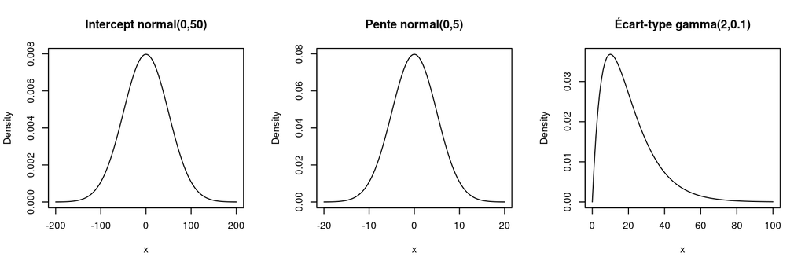

```r
par(mfrow=c(1,3))
curve(dnorm(x,0,50),from=-200,to=200,main="Intercept normal(0,50)",ylab="Density")
curve(dnorm(x,0,5),from=-20,to=20,main="Pente normal(0,5)",ylab="Density")
curve(dgamma(x,2,0.1),from=0,to=100,main="Écart-type gamma(2,0.1)",ylab="Density")
```

Par exemple, pour la variance/écart-type du modèle, il faut idéalement un *prior* avec des valeurs strictement positives, car les valeurs négatives ne font pas de sens pour la variance. Une des possibilités est d’utiliser la distribution gamma.

### Modèle avec brms

La façon la plus “clé en main” de faire un modèle bayésien est d’utiliser le package brms. Ce package permet de spécifier des modèles d’une façon très similaire aux packages fréquemment utilisés comme nlme, lme4, glmmTMB, etc. En arrière-plan, brms utilise le programme [STAN](https://mc-stan.org/) qui est un environnement de programmation pour la modélisation bayésienne.

```r
library(brms)

m <- brm(y ~ x,
       data = d,
       cores = 3,
       chains = 3,
       family = "gaussian",
       prior = c(
         set_prior("normal(0,5)", class = "b", coef="x"),
         set_prior("normal(0,50)", class = "Intercept"),
         set_prior("gamma(2,0.1)", class = "sigma")
       )
     )
```

### Visualisation

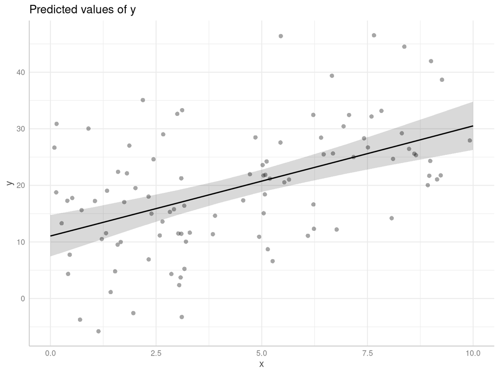

```r
library(ggeffects)
g <- ggpredict(m, terms = c("x"))
plot(g, show_data = TRUE)
```

### Distribution postérieure des prédictions

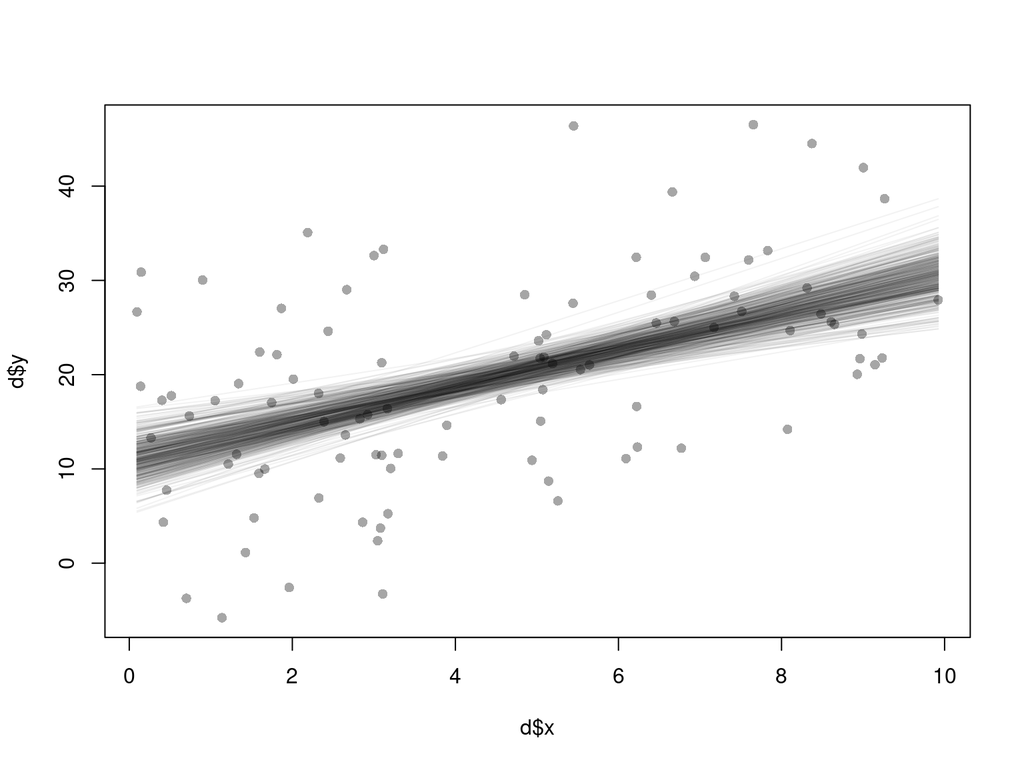

```r
newdata <- data.frame(x = seq(min(d$x), max(d$x), length.out = 100))

pp <- posterior_epred(m, newdata, ndraws = 500)

plot(d$x, d$y, ylim = range(c(pp, d$y)), pch = 16, col = gray(0, 0.35))
lapply(1:nrow(pp), function(i){
  lines(newdata$x, pp[i, ], col = adjustcolor("black", 0.05))
}) |> invisible()
```

### Formulation du modèle

On a la composante aléatoire, la composante systématique et les *priors*.

$$y \sim
\mathcal{N}(\mu,\sigma^2)$$
$$\mu =
\beta_{0}+\beta_{1}x$$
$$\beta_{0}
\sim \mathcal{N}(0,50)$$
$$\beta_{1}
\sim \mathcal{N}(0,5)$$
$$\sigma \sim
\mathcal{Gamma}(2,0.1)$$

### Sommaire

```r
summary(m)
```

```
##  Family: gaussian
##   Links: mu = identity
## Formula: y ~ x
##    Data: d (Number of observations: 100)
##   Draws: 3 chains, each with iter = 2000; warmup = 1000; thin = 1;
##          total post-warmup draws = 3000
##
## Regression Coefficients:
##           Estimate Est.Error l-95% CI u-95% CI Rhat Bulk_ESS Tail_ESS
## Intercept    11.05      1.83     7.44    14.76 1.00     2933     2285
## x             1.94      0.35     1.28     2.62 1.00     2514     2017
##
## Further Distributional Parameters:
##       Estimate Est.Error l-95% CI u-95% CI Rhat Bulk_ESS Tail_ESS
## sigma     9.69      0.71     8.47    11.24 1.00     2656     1894
##
## Draws were sampled using sampling(NUTS). For each parameter, Bulk_ESS
## and Tail_ESS are effective sample size measures, and Rhat is the potential
## scale reduction factor on split chains (at convergence, Rhat = 1).
```

Notez encore une fois ici qu’on peut faire une interprétation probabiliste plus naturelle des intervalles de confiance. Contrairement aux analyses fréquentistes, on peut dire que le probabilité que la valeur d’un paramètre soit entre les bornes inférieures et supérieures d’un intervalle de confiance à 95% est de 95%. En fait, avec une approche bayésienne, on parle plutôt d’intervalle de crédibilité (*credible interval*).

### Visualisation des paramètres

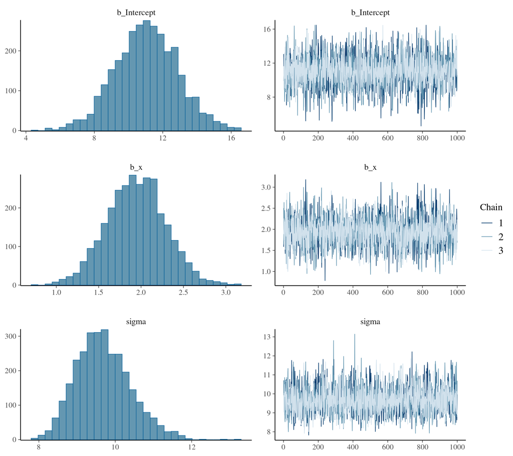

```r
plot(m)
```

Les distributions postérieures des paramètres sont illustrées à gauche. À droite, les chaînes de MCMC sont illustrées (nous y reviendrons).

## MCMC

Le MCMC (*Markov Chain Monte Carlo*) est une classe d’algorithmes permettant d’échantillonner à partir d’une distribution de probabilité. Il s’agit d’une approche qui permet d’éviter des calculs complexes, voire impossible, en utilisant une approche d’échantillonnage.  
Dans un contexte bayésien, le MCMC permet d’échantillonner à partir d’une distribution postérieure. Autrement dit, la distribution postérieure de chaque paramètre estimé dans un contexte bayésien peut entre autre être obtenue par cette méthode d’échantillonnage.  
Sous certaines conditions, les valeurs échantillonnées représenteront la distribution postérieure de chaque paramètre.

### Échantillonnage des chaînes

L’échantillonnage par MCMC se fait de façon séquentielle, *i.e.* que les valeurs seront échantillonnées les unes à la suite des autres. Dans bien des cas, les valeurs actuelles seront dépendentes (corrélées) des valeurs précédentes. On peut parler ici de chaînes pour désigner l’ensemble des valeurs échantillonnées de façon séquentielle.  
Pour démarrer chaque chaîne, il faut d’abord sélectionner une valeur de départ pour chaque paramètre estimé. Cette valeur de départ peut potentiellement être très loin d’une valeur probable.  
Éventuellement, les chaînes vont s’éloigner de ces valeurs de départ pour converger vers les distributions postérieures. À ce moment, on dira que l’échantillonnage se fait véritablement à partir des distributions postérieures.

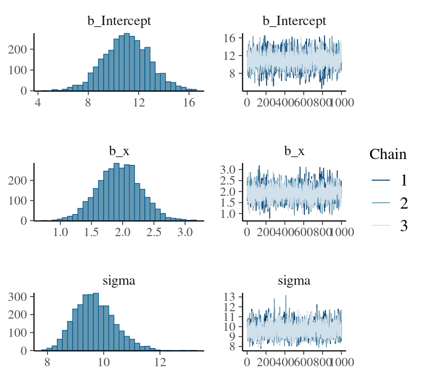

```r
plot(m)
```

### Convergence des chaînes

Avec les analyses bayésiennes où les paramètres sont estimés par MCMC, il faut donc vérifier la convergence des chaînes pour s’assurer que les valeurs échantillonnées représentent bien les distributions postérieures.  
On élimine souvent une certaine portion du début des chaînes pour enlever les valeurs échantillonnées, alors que les chaînes n’ont pas convergé. On parle souvent de *burnin* pour désigner cette partie des chaînes.  
Il est également très fréquent d’utiliser plusieurs chaînes (3-4) pour un même paramètre ce qui permet de s’assurer que les chaînes ont toutes convergé au même endroit. En général, on choisira des valeurs de départ différentes pour chacune des chaînes.  
On peut vérifier la convergence des chaînes avec entre autres le `Rhat` (*potential scale reduction statistic* ou *Gelman-Rubin statistic*). Intuitivement, pour un paramètre donné, cette valeur compare la variance inter-chaîne à la variance intra-chaîne pour évaluer si les chaînes ont convergé au même endroit. Si c’est le cas, le `Rhat` sera très près de 1 (`Rhat` <= 1.01)

```r
summary(m)
```

```
##  Family: gaussian
##   Links: mu = identity
## Formula: y ~ x
##    Data: d (Number of observations: 100)
##   Draws: 3 chains, each with iter = 2000; warmup = 1000; thin = 1;
##          total post-warmup draws = 3000
##
## Regression Coefficients:
##           Estimate Est.Error l-95% CI u-95% CI Rhat Bulk_ESS Tail_ESS
## Intercept    11.05      1.83     7.44    14.76 1.00     2933     2285
## x             1.94      0.35     1.28     2.62 1.00     2514     2017
##
## Further Distributional Parameters:
##       Estimate Est.Error l-95% CI u-95% CI Rhat Bulk_ESS Tail_ESS
## sigma     9.69      0.71     8.47    11.24 1.00     2656     1894
##
## Draws were sampled using sampling(NUTS). For each parameter, Bulk_ESS
## and Tail_ESS are effective sample size measures, and Rhat is the potential
## scale reduction factor on split chains (at convergence, Rhat = 1).
```

## Priors

L’utilisation de *priors* est souvent vue comme étant la partie la plus controversée des statistiques bayésiennes. Qu’en pensez-vous?  
Idéalement, il faut toujours avoir une bonne idée de l’influence des *priors* sur nos analyses. Pour cela il est bien de comparer les distributions postérieures aux *priors*. On peut également faire dans certains cas des analyses de sensibilité pour quantifier cette influence.  
Plus on a de données, moins les *priors* auront d’influence sur l’estimation des paramètres.

### Types de *priors*

- Informatif: basé sur la théorie, reflète les connaissances.
- Non-informatif: reflète l’absence de connaissances ou le désir de ne pas influencer les résultats.
- Plat (*flat*): similaire à non-informatif.
- Légèrement informatif (*weaky informative*): la théorie n’est pas assez développée pour utiliser des *priors* informatifs, mais assez pour savoir que certaines valeurs ne sont pas probables.
- Par défaut: valeurs par défaut utilisées par les logiciels ou les packages.
- Régularisant (*regularizing*): permet de circonscrire les valeurs obtenues et de pénaliser les valeurs élevées dans un contexte prédictif.
- Etc.

Voir notamment [Lemoine 2019](https://doi.org/10.1111/oik.05985) et [Banner et al. 2020](https://doi.org/10.1111/2041-210X.13407) pour une discussion sur l’utilisation des priors en écologie.

### Quels *priors* utiliser?

Il faut aussi sélectionner une distribution approriée pour représenter nos *priors* et les distributions utilisées doivent être appropriées pour un paramètre donné. Le groupe qui travaille sur la plateforme [STAN](https://mc-stan.org/) a plusieurs recommandations de *priors* à utiliser dépendemment du contexte (*priors* pour des pentes, *priors* pour des variances, *priors* pour des variances dans un contexte de modèles hiérarchiques, etc.)

Voir [*Prior Choice Recommendations*](https://github.com/stan-dev/stan/wiki/Prior-Choice-Recommendations) pour des recommandations.

### Attention aux *priors* “non-informatifs”!

Les *priors* non-informatifs ne le sont pas toujours sous l’échelle du paramètre. Par exemple, si vous tentez d’estimer une probabilité et que vous utiliser une distribution normale comme *prior* pour l’intercept du modèle, il se peut que ce *prior* soit très informatif sous l’échelle du prédicteur linéaire qui est relié à la probabilité par une fonction logit. Supposons un glm binomial avec seulement un intercept.
$$y \sim \mathcal{Binom}(1,p) =
\mathcal{Bernoulli}(p)$$
$$logit(p) = log\left(\frac{p}{1-p}\right) = \beta_{0}$$
$$\beta_{0} \sim \mathcal{N}(0,10)$$

### Attention aux *priors* “non-informatifs”!

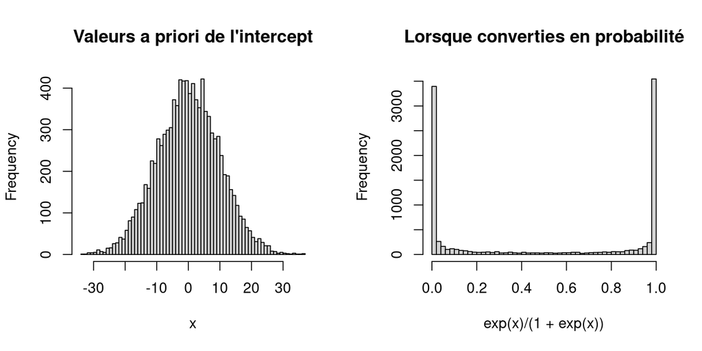

```r
n<-10000
x<-rnorm(n,0,10)
par(mfrow=c(1,2))
hist(x,breaks=50,main="Valeurs a priori de l'intercept")
hist(exp(x)/(1+exp(x)),breaks=50,main="Lorsque converties en probabilité")
```

Autrement dit, le *prior* est très informatif et pousse les valeurs vers des probabilités extrêmes!

### Étudier ses priors

La distribution prédictive préalable (*Prior predictive distribution*) permet de visualiser l’effet des priors sur l’échelle de la réponse.

```r
m2 <- update(m, sample_prior = "only")
```

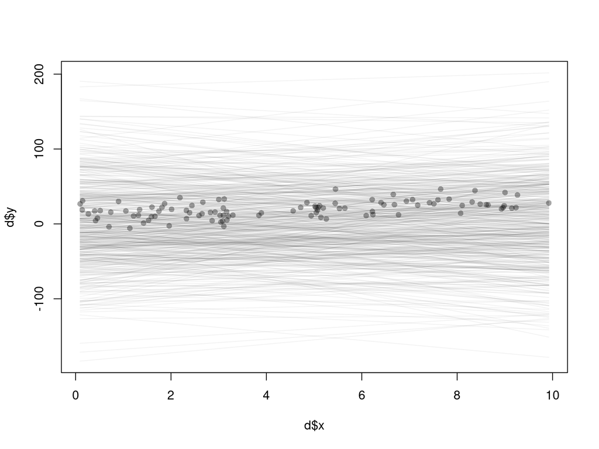

```r
newdata <- data.frame(x = seq(min(d$x), max(d$x), length.out = 100))

pp <- posterior_epred(m2, newdata, ndraws = 500)

plot(d$x, d$y, ylim = range(c(pp, d$y)), pch = 16, col = gray(0, 0.35))
lapply(1:nrow(pp), function(i){
  lines(newdata$x, pp[i, ], col = adjustcolor("black", 0.05))
}) |> invisible()
```

#### Avec un *prior* aberrant

```r
newdata <- data.frame(x = seq(min(d$x), max(d$x), length.out = 100))

m3 <- update(m,
        sample_prior = "only",
        prior = c(
           set_prior("normal(50,20)", class = "b", coef="x"),
           set_prior("normal(0,50)", class = "Intercept"),
           set_prior("gamma(2,0.1)", class = "sigma")
        ),
      )
```

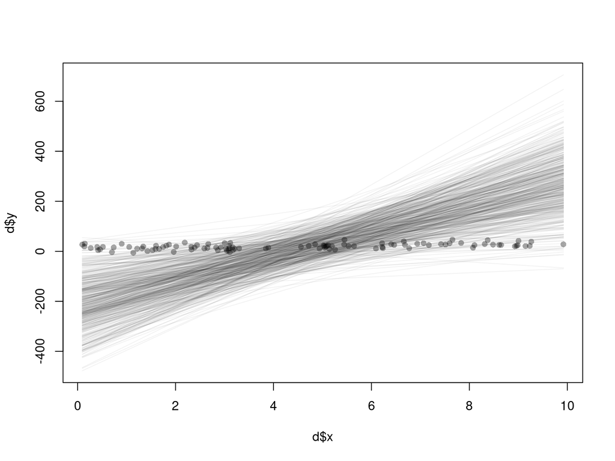

```r
pp <- posterior_epred(m3, newdata, ndraws = 500)

plot(d$x, d$y, ylim = range(c(pp, d$y)), pch = 16, col = gray(0, 0.35))
lapply(1:nrow(pp), function(i){
  lines(newdata$x, pp[i, ], col = adjustcolor("black", 0.05))
}) |> invisible()
```

#### Avec un modèle binomial

```r
logit <- function(p) {
  log(p / (1 - p))
}

inv.logit <- function(x) {
   exp(x) / (1 + exp(x))
}

n <- 200
x <- runif(n, 0, 10)
z <- -2 + 0.5 * x
y <- rbinom(n, size = 1, prob = inv.logit(z))

d<-data.frame(y,x)

m <- brm(y ~ x,
       data = d,
       cores = 3,
       chains = 3,
       family = "bernoulli",
       prior = c(
         set_prior("normal(0,5)", class = "b", coef="x"),
         set_prior("normal(0,5)", class = "Intercept")
       )
     )
```

#### Distribution postérieure des prédictions

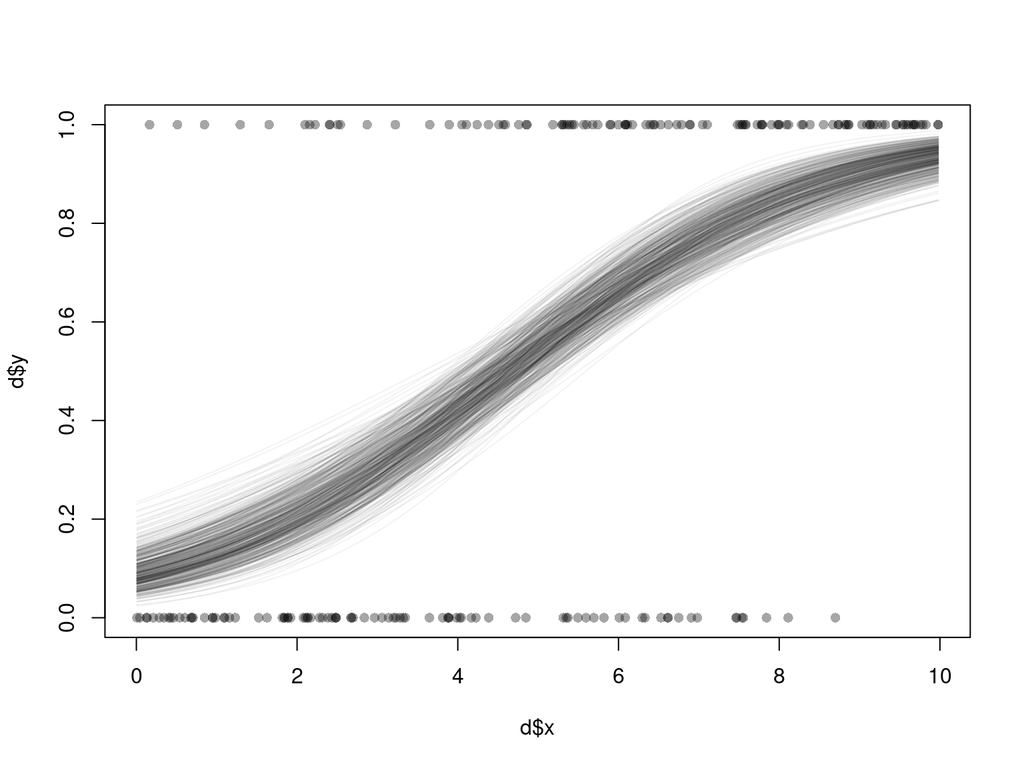

```r
newdata <- data.frame(x = seq(min(d$x), max(d$x), length.out = 100))

pp <- posterior_epred(m, newdata, ndraws = 500)

plot(d$x, d$y, ylim = range(c(pp, d$y)), pch = 16, col = gray(0, 0.35))
lapply(1:nrow(pp), function(i){
  lines(newdata$x, pp[i, ], col = adjustcolor("black", 0.05))
}) |> invisible()
```

#### Ce qu’indique notre *prior*

```r
m2 <- update(m, sample_prior = "only")
```

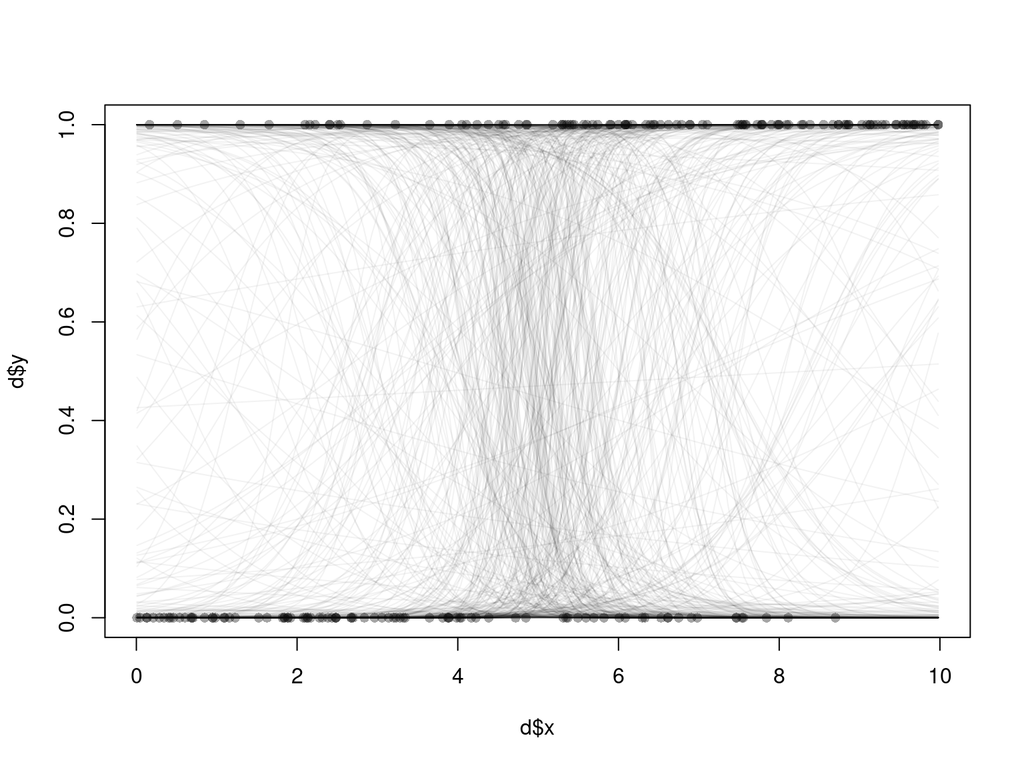

```r
pp <- posterior_epred(m2, newdata, ndraws = 500)

plot(d$x, d$y, ylim = range(c(pp, d$y)), pch = 16, col = gray(0, 0.35))
lapply(1:nrow(pp), function(i){
  lines(newdata$x, pp[i, ], col = adjustcolor("black", 0.05))
}) |> invisible()
```

#### Prédiction pour `x = 2`

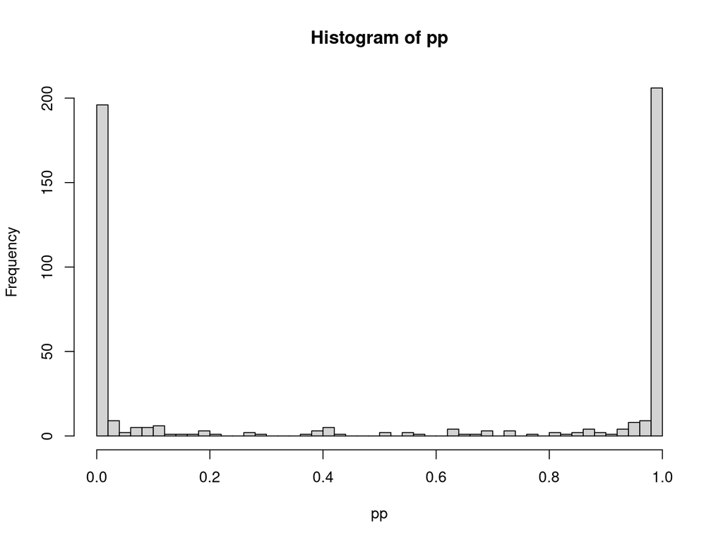

```r
pp <- posterior_epred(m2, data.frame(x = 2), ndraws = 500)
hist(pp, breaks = 50)
```

### Un *prior* plus raisonnable?

```r
m3 <- update(m,
       sample_prior = "only",
       prior = c(
         set_prior("normal(0,1)", class = "b", coef="x"),
         set_prior("normal(0,1)", class = "Intercept")
       )
     )
```

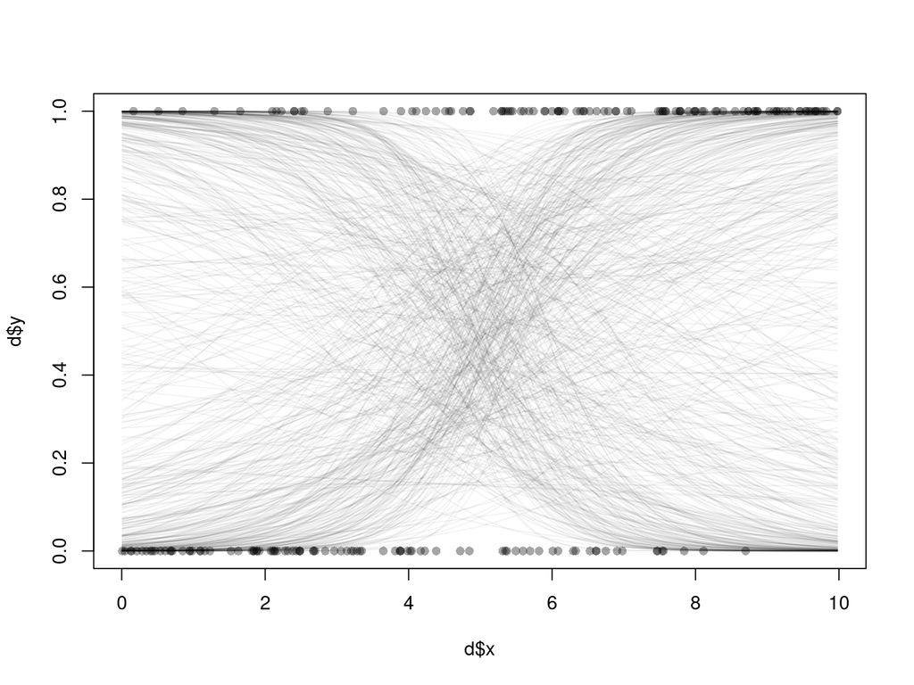

```r
pp <- posterior_epred(m3, newdata, ndraws = 500)

plot(d$x, d$y, ylim = range(c(pp, d$y)), pch = 16, col = gray(0, 0.35))
lapply(1:nrow(pp), function(i){
  lines(newdata$x, pp[i, ], col = adjustcolor("black", 0.05))
}) |> invisible()
```

## Recommandations sur les priors

[**Prior Choice Recommendations**](https://github.com/stan-dev/stan/wiki/Prior-Choice-Recommendations) Recommandation par les développeurs de STAN

[**Moving beyond noninformative priors: why and how to choose weakly informative priors in Bayesian analyses**](https://doi.org/10.1111/oik.05985)

[**The use of Bayesian priors in Ecology: The good, the bad and the not great**](https://doi.org/10.1111/2041-210X.13407)

[**Choosing priors in Bayesian ecological models by simulating from the prior predictive distribution**](https://doi.org/10.1002/ecs2.3739)

## Outils

Il existe plusieurs outils pour faire des modèles bayésiens.

[**WinBUGS**](https://www.mrc-bsu.cam.ac.uk/software/bugs/the-bugs-project-winbugs/) Un des premiers outils, mais un peu lent  
[**JAGS**](https://sourceforge.net/projects/mcmc-jags/files/Manuals/) Similaire à BUGS, mais un peu plus rapide  
[**STAN**](https://mc-stan.org/) Rapide et bien documenté  
[**Nimble**](https://r-nimble.org/) Relativement nouveau  
[**MCMCglmm**](https://CRAN.R-project.org/package=MCMCglmm) Modèle animal?  
[**brms**](https://CRAN.R-project.org/package=brms) Facile d’utilisation et basé sur STAN  
[**INLA**](https://www.r-inla.org/) Modèles spatiaux

# Liens utiles

[A protocol for data exploration to avoid common statistical problems](https://doi.org/10.1111/j.2041-210X.2009.00001.x)

[A protocol for conducting and presenting results of regression-type analyses](https://doi.org/10.1111/2041-210X.12577)

[Applied statistics in ecology: common pitfalls and simple solutions](https://doi.org/10.1890/ES13-00160.1)

[Simple means to improve the interpretability of regression coefficients](https://doi.org/10.1111/j.2041-210X.2010.00012.x)